# Analysis of Data from personal activity monitoring device

Objective: Demonstrate learning from the Reproducible Research lectures.

## Loading and preprocessing the data

1. We first load the data provided in the course webpage.

```r
setwd("C:/Users/weijie/Desktop/Coursera R course/V. Reproducible Research")
fileUrl <- "http://d396qusza40orc.cloudfront.net/repdata%2Fdata%2Factivity.zip"
temp <- tempfile()
download.file(fileUrl,temp)
data <- read.csv(unz(temp,"activity.csv"))
data[,2] <- as.Date(data[,2])
```

2. Process/transform data into a suitable format.

```r
#I am choosing to construct another dataset, data1, for daily values. This would be useful for subsequent analyses.
n <- 24*60/5
grp <- seq(1,nrow(data),by=n)
dailysteps <- sapply(grp, function(x) sum(data[x:(x+n-1),1]))
#data1 is a dataset of the total number of steps taken, on a daily basis
data1 <- matrix(nrow=length(grp),ncol=2)
colnames(data1)<-c("steps","date")
for(i in 1:length(grp)){
        data1[i,1] <- dailysteps[i]
        data1[i,2] <- as.character(data[grp[i],2])
}
```

## Computing the mean total number of steps taken per day

1. Histogram of the total number of steps taken each day.

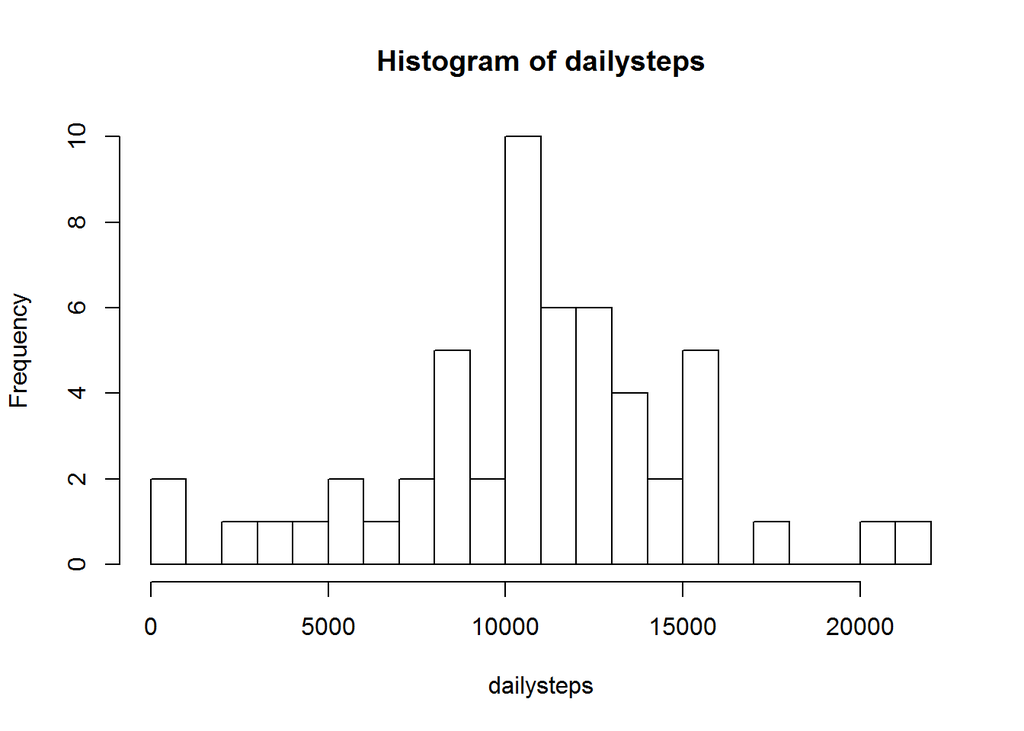

```r
hist(dailysteps,breaks=20)
```

```r
meandailysteps <- mean(dailysteps,na.rm=TRUE)
mediandailysteps <- median(dailysteps,na.rm=TRUE)
```

## Average daily activity pattern

1. Time-series plot of the 5-min interval (x-axis) and the average number of steps taken, averaged across all days (y-axis).

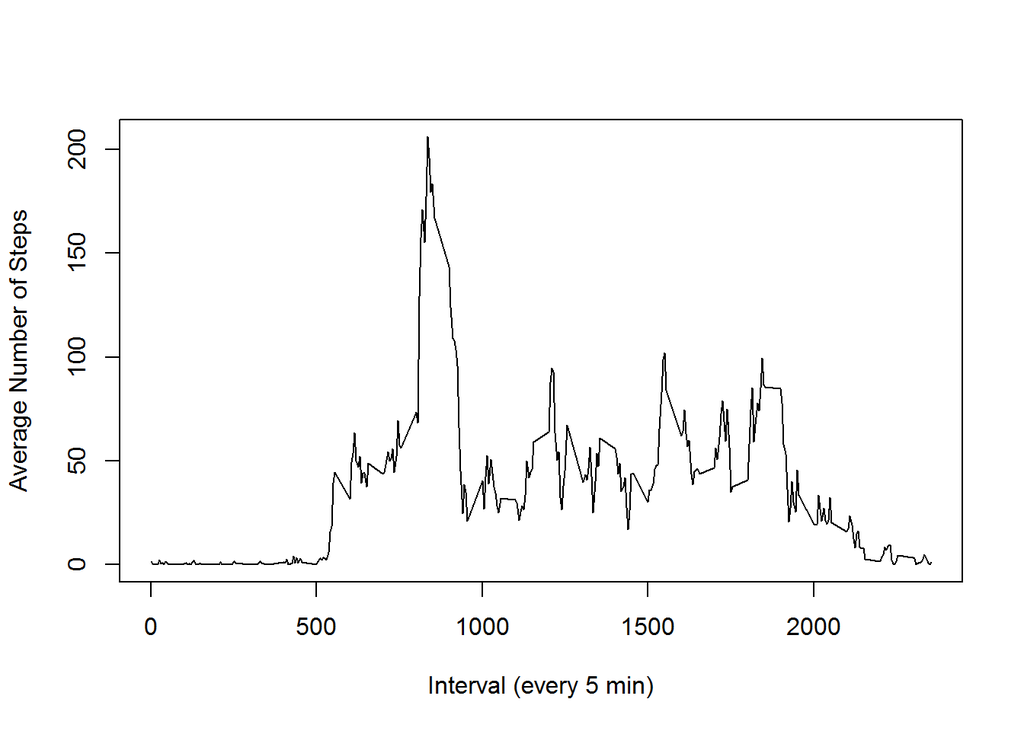

```r
data2 <- aggregate(.~data$interval,FUN=mean,na.rm=TRUE,data=data)
plot(data2$interval,data2$steps,type="l",xlab="Interval (every 5 min)",ylab="Average Number of Steps")
```

2. Which 5-minute interval, on average across all the days in the dataset, contains the maximum number of steps?

```r
data2[which.max(data2$steps),1]
```

```
## [1] 835
```

## Imputing missing values

1. Calculate total number of missing values in the dataset

```r
number_of_NAs=0
for(i in 1:nrow(data)){
        if(is.na(data[i,1])==TRUE){
                number_of_NAs=number_of_NAs+1
        }
}
number_of_NAs
```

```
## [1] 2304
```

2. Devise a strategy for filling in all of the missing values in the dataset. CHOSEN STRATEGY: USE THE MEAN FOR THAT 5-MINUTE INTERVAL.
3. Create a new dataset, with the missing data filled in, using the chosen strategy.

```r
newdata <- as.data.frame(matrix(nrow=nrow(data),ncol=4))
colnames(newdata)<-c("steps","date","interval","weekday")
for(i in 1:nrow(data)){
        if(is.na(data[i,1]==TRUE)){
                int <- data[i,3]
                newdata[i,1] <- data2[which(data2$interval==int),2]
        } else {
                newdata[i,1] <- as.numeric(data[i,1])
        }
        newdata[i,2] <- data[i,2]
        newdata[i,3] <- data[i,3]
}
```

4. Make a histogram of the revised total number of steps taken each day. Calculate the mean and median total number of steps taken per day.

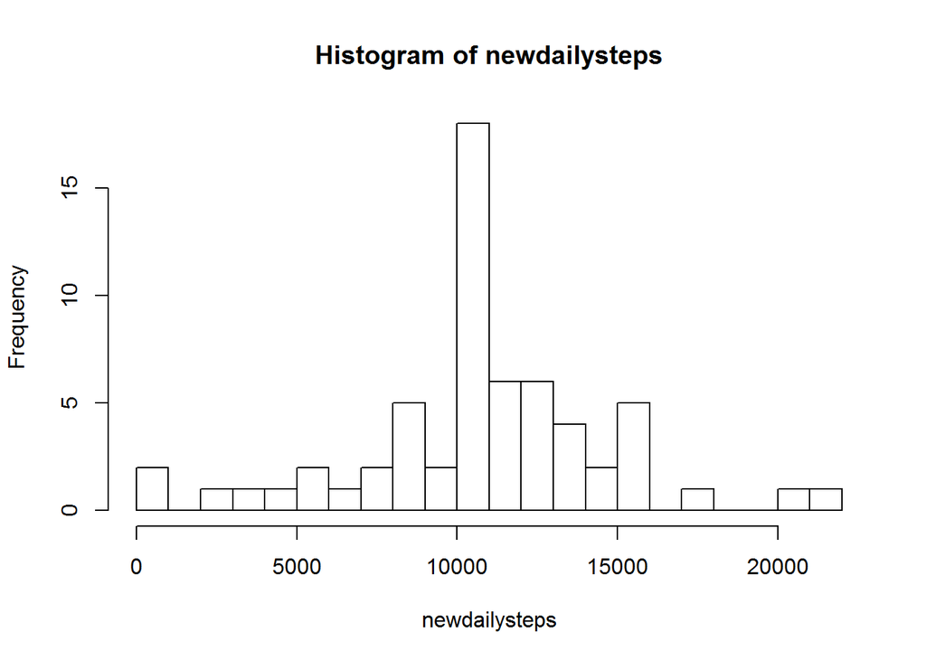

```r
newdailysteps <- sapply(grp, function(x) sum(as.numeric(newdata[x:(x+n-1),1])))
hist(newdailysteps,breaks=20)
```

```r
newmeandailysteps <- mean(newdailysteps,na.rm=TRUE)
newmediandailysteps <- median(newdailysteps,na.rm=TRUE)
#Computing the differences from the previous estimates
Diff_in_new_mean <- newmeandailysteps - meandailysteps
Diff_in_new_median <- newmediandailysteps - mediandailysteps
```

There is no change in the mean, whilst the median has increased by 1.1886792.

1. Create a new factor variable in the dataset with two levels: “weekday” and “weekend”.

```r
for(i in 1:nrow(newdata)){
        newdata[i,4] <- "weekday"
}
x <- c(6,13,20,27,34,41,48,55)
for(j in seq_along(x)){
        for(k in grp[j]:grp[j]+2*288-1){
                newdata[k,4] <- "weekend"
        }
}
```

```r
#data3 <- aggregate(.~newdata$interval,FUN=mean,na.rm=TRUE,data=newdata)
#plot(data3$interval,data3$weekday,type="l",xlab="Interval (every 5 min)",ylab="Weekend or Weekday")
```